# 火锅案例分析

Cheng Zhong，16307110259

2019年4月15日

- **准备工作**

```r
#清除工作环境
cat("\014");rm(list=ls())
```

```r
# 加载包
library(dplyr)
library(plyr)
library(stringr)
library(lubridate)
```

```r
library(ggplot2)
library(gridExtra)
library(RColorBrewer)
library(MASS)
library(tm)
library(jiebaR)
library(wordcloud2)
library(pROC)
library(ROCR)
setwd('E:\\Rdata')
```

这里因为Rwordseg包在机器上无法安装，使用另一分词包jiebaR代替

- **任务一**

```r
#Mission I
hotpot <- read.csv("HotPotForMac.csv",fileEncoding = 'UTF-8',sep = ',') #读入数据
hotpot$字段1 <- as.character(hotpot$字段1)
hotpot$字段2 <- as.character(hotpot$字段2)  #转换类型
summary(hotpot)
```

```
##        ID            字段1              字段2              discount
##  Min.   :   1.0   Length:2688        Length:2688        Min.   :0.01429
##  1st Qu.: 749.8   Class :character   Class :character   1st Qu.:0.63762
##  Median :1540.5   Mode  :character   Mode  :character   Median :0.76336
##  Mean   :1548.1                                         Mean   :0.72725
##  3rd Qu.:2350.2                                         3rd Qu.:0.85000
##  Max.   :3150.0                                         Max.   :0.99900
##
##      price                    privilege.for.new  privilege.on.sale
##  Min.   :   1.00   钱包新客最高再减20元:2639    无立减优惠:2537
##  1st Qu.:  68.00   无钱包新客优惠      :  49    有立减优惠: 151
##  Median :  86.05
##  Mean   : 109.74
##  3rd Qu.: 135.25
##  Max.   :1365.00
##
##     district           if.nonworkdays.available time.duration
##  未央区 :531   非周末法定节假日通用: 403        Min.   : 0.00
##  雁塔区 :436   周末法定节假日通用  :2285        1st Qu.:10.00
##  碑林区 :367                                    Median :11.00
##  莲湖区 :356                                    Mean   :10.67
##  长安区 :231                                    3rd Qu.:12.00
##  新城区 :173                                    Max.   :24.00
##  (Other):594
##  if.appointment.needed  WiFi.available       parking
##  无需预约:2474         免费WiFi:2103   免费停车位: 479
##  需预约  : 214         未提及  : 585   收费停车位: 203
##                                        未提及    :1412
##                                        无停车位  : 594
##
##
##
##      rooms.available      评分           评论数        online.intervel
##  仅限大厅使用:1937   Min.   :0.000   Min.   :   0.00   Min.   :   1.0
##  均可使用    : 500   1st Qu.:0.000   1st Qu.:   0.00   1st Qu.: 191.0
##  未提及      : 251   Median :4.400   Median :   3.00   Median : 320.5
##                      Mean   :3.167   Mean   :  54.49   Mean   : 341.2
##                      3rd Qu.:4.700   3rd Qu.:  22.00   3rd Qu.: 467.0
##                      Max.   :5.000   Max.   :8032.00   Max.   :1143.0
##
```

[output cut: 9 more lines]

```
##  不限张数:2263            否:2108   否:1824   否:2123   否:2150
##  限制张数: 425            是: 580   是: 864   是: 565   是: 538
##
##
##
##
##
##  people     style         HighFreq
##  否:2497   北系: 142   Min.   :0.000
##  是: 191   川系: 861   1st Qu.:1.000
##            其他:1619   Median :2.000
##            粤系:  66   Mean   :1.924
##                        3rd Qu.:3.000
##                        Max.   :6.000
##
```

- **任务二**

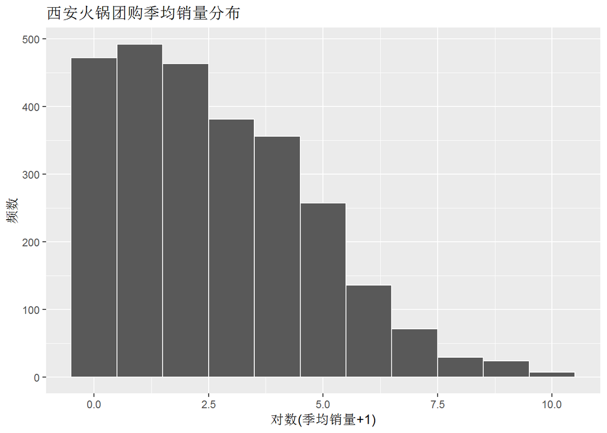

```r
#Mission II
hotpot$logquarterly.sales.volume <- log(hotpot$quarterly.sales.volume + 1)
ggplot(hotpot,aes(x = logquarterly.sales.volume)) + geom_histogram(binwidth=1,colour = "white") + xlab ("对数(季均销量+1)") + ylab ("频数") + ggtitle("西安火锅团购季均销量分布")
```

```r
summary(hotpot$quarterly.sales.volume)
```

```
##      Min.   1st Qu.    Median      Mean   3rd Qu.      Max.
##     0.000     1.415     9.441   223.914    55.794 25941.429
```

```r
length(which((hotpot[,18]== 0))) #销量为0的店铺
```

```
## [1] 276
```

使用季均销量的对数值是因为季均销量值域较大，最小值与最大值差距大，数值分布较为离散，直接使用会造成拟合不准确等问题。

- **任务三**

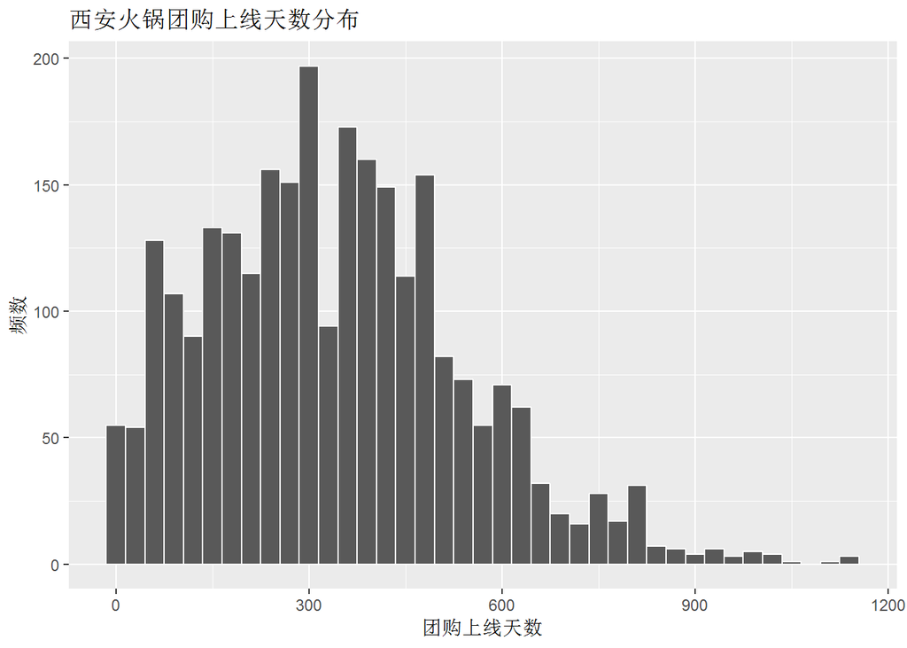

```r
#Mission III
ggplot(hotpot,aes(x = online.intervel)) + geom_histogram(binwidth=30,colour = "white") + xlab ("团购上线天数") + ylab ("频数") + ggtitle("西安火锅团购上线天数分布")
```

```r
hotpot$discountpercent <- 100 * hotpot$discount
```

```r
summary(hotpot$online.intervel)
```

```
##    Min. 1st Qu.  Median    Mean 3rd Qu.    Max.
##     1.0   191.0   320.5   341.2   467.0  1143.0
```

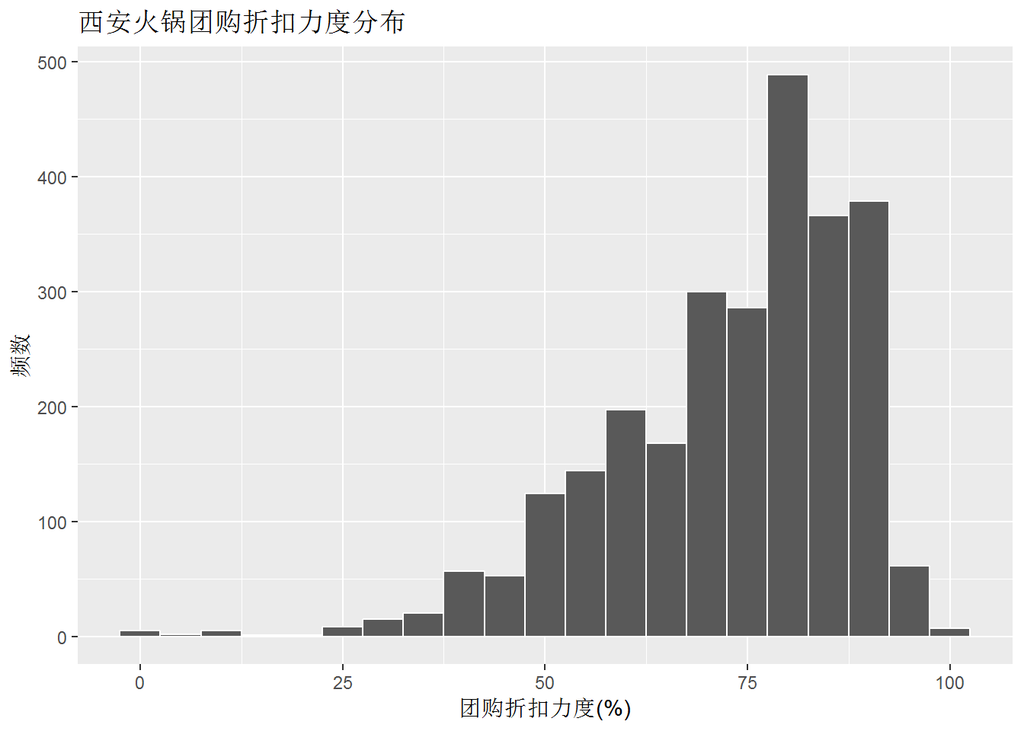

```r
ggplot(hotpot,aes(x = discountpercent)) + geom_histogram(binwidth=5,colour = "white") + xlab ("团购折扣力度(%)") + ylab ("频数") + ggtitle("西安火锅团购折扣力度分布")
```

```r
summary(hotpot$discount)
```

```
##    Min. 1st Qu.  Median    Mean 3rd Qu.    Max.
## 0.01429 0.63762 0.76336 0.72725 0.85000 0.99900
```

- **任务四**

```r
#Mission IV
fenci <- function(seq)
{
  seq <- qseg[seq]
  seq <- table(seq)
  seq <- seq[!grepl('[a-zA-Z0-9]+',names(seq))]
  seq <- seq[!grepl('店',names(seq))]
  seq <- seq[!grepl('小火锅',names(seq))]
  seq <- seq[!grepl('区',names(seq))]
  seq <- seq[!grepl('路',names(seq))]
  seq <- seq[!grepl('店',names(seq))]
  seq <- sort(seq,decreasing = TRUE)
}  #分词并去除一些无关词
title <- fenci(hotpot$字段1)
```

```r
wordcloud2(title,size = 2,fontFamily = "微软雅黑",color = "random-light")
```

[interactive chart not shown]

从词云中可以看到火锅店名高频词主要有，与火锅常见食物有关的串串，鱼，肥牛；与火锅有关的城市重庆，成都，以及与火锅吃法相关的焖，涮，煲，麻辣，炝等，都具有相当明显的火锅特征。

- **任务五**

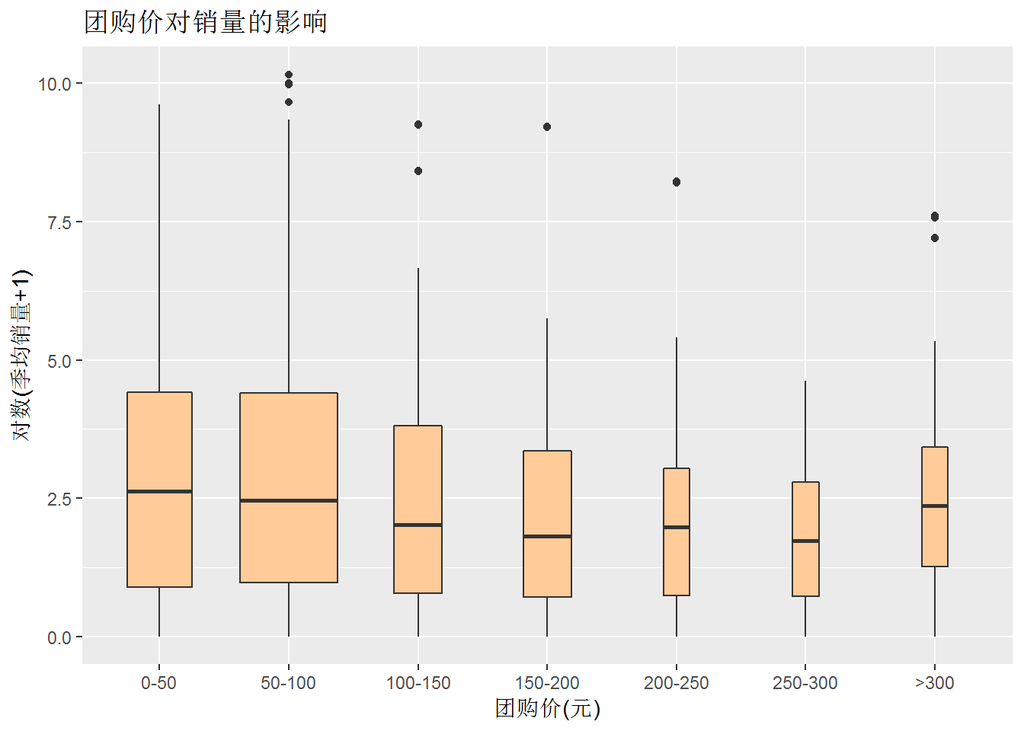

```r
hotpot[(hotpot$price > 300),30] <- ">300"
hotpot[((hotpot$price > 250)&(hotpot$price <= 300)),30] <- "250-300"
hotpot[((hotpot$price > 200)&(hotpot$price <= 250)),30] <- "200-250"
hotpot[((hotpot$price > 150)&(hotpot$price <= 200)),30] <- "150-200"
hotpot[((hotpot$price > 100)&(hotpot$price <= 150)),30] <- "100-150"
hotpot[((hotpot$price > 50)&(hotpot$price <= 100)),30] <- "50-100"
hotpot[(hotpot$price <= 50),30] <- "0-50"
hotpot$V30 <- factor(hotpot$V30,levels = c("0-50","50-100","100-150","150-200","200-250","250-300",">300")) #数据准备
ggplot(data = hotpot,aes(x = V30, y = logquarterly.sales.volume))  + geom_boxplot(fill = "#FFCC99",varwidth = TRUE) +labs(title = "团购价对销量的影响", x = '团购价(元)', y = '对数(季均销量+1)')
```

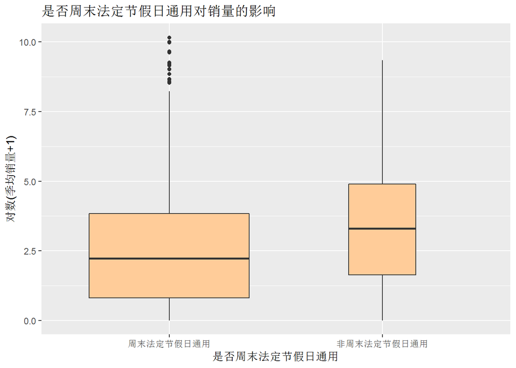

```r
hotpot$if.nonworkdays.available <- factor(hotpot$if.nonworkdays.available ,levels = c("周末法定节假日通用","非周末法定节假日通用"))
ggplot(data = hotpot,aes(x = if.nonworkdays.available, y = logquarterly.sales.volume))  + geom_boxplot(fill = "#FFCC99",varwidth = TRUE) + labs(title = "是否周末法定节假日通用对销量的影响", x = "是否周末法定节假日通用", y = '对数(季均销量+1)')
```

对于是否法定节假日通用，非周末法定节假日通用比周末法定节假日通用具有更高的团购量，可能是因为消费者并不关心这一项，也有可能是数据量不够造成的偏差。

- **任务六**

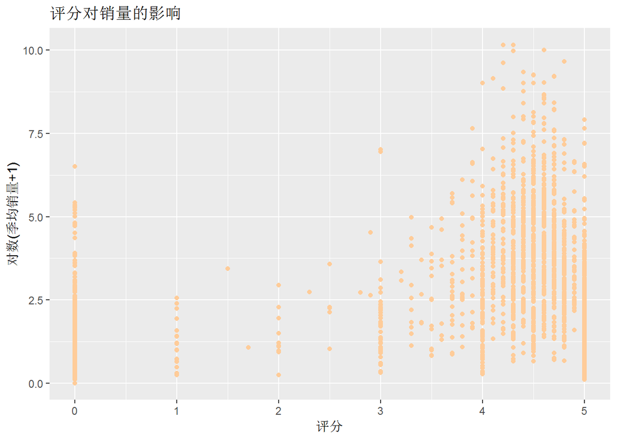

```r
#Mission vI
ggplot(data = hotpot,mapping = aes(x = 评分, y = logquarterly.sales.volume)) + geom_point(colour = "#FFCC99") + labs(title = "评分对销量的影响", x = "评分", y = '对数(季均销量+1)')
```

从图中可以看出，大部分的火锅店评分都集中在4分到5分之间，关于0分的店可能是没有相关数据所致；而评分较高的火锅店团购销量也相对更高。

- **任务七**

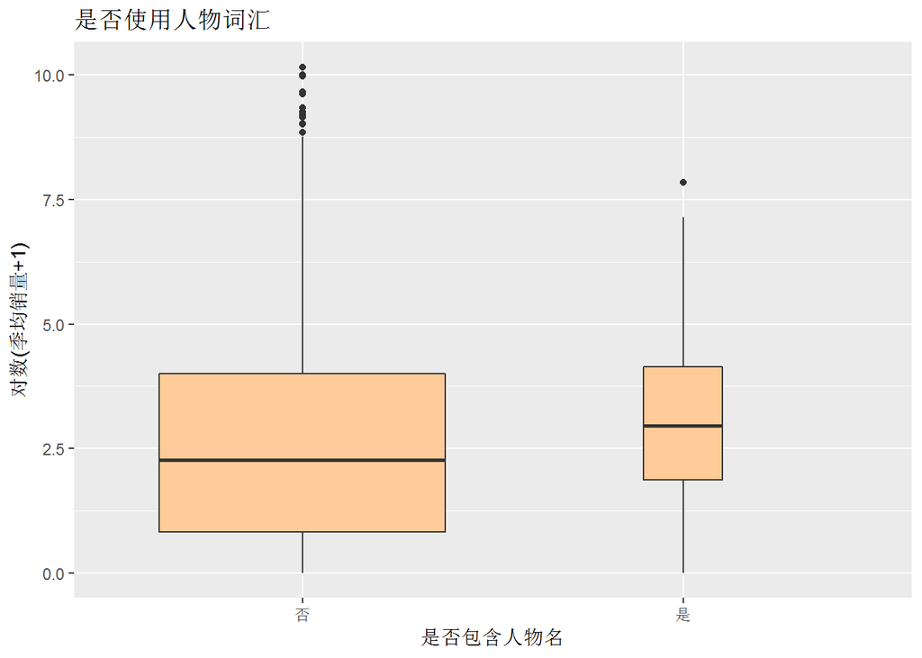

```r
ggplot(data = hotpot,aes(x = people, y = logquarterly.sales.volume))  + geom_boxplot(fill = "#FFCC99",varwidth = TRUE) + labs(title = "是否使用人物词汇", y = '对数(季均销量+1)',x = "是否包含人物名")
```

从图中可以看出，在店名中包含人物名可以提高店铺的团购量，可能是由于含人物名的店名可以让消费者觉得更加亲切，从而刺激消费者的消费欲望。

-**任务八**

```r
a <- mean(hotpot$logquarterly.sales.volume) #计算平均值
hotpot$high <- 0
hotpot$high[hotpot$quarterly.sales.volume >= a] <- 1
hotpot$privilege.for.new <- factor(hotpot$privilege.for.new,levels = c("无钱包新客优惠","钱包新客最高再减20元","有立减优惠"))
hotpot$parking <- factor(hotpot$parking,levels = c("免费停车位","收费停车位","无停车位","未提及"))
hotpot$style <- factor(hotpot$style,levels = c("其他","北系","川系","粤系"))
hotpot$district <- factor(hotpot$district,levels = c("临潼区","新城区","未央区","灞桥区","碑林区","莲湖区","长安区","阎良区","雁塔区","高新区"))
     #调整变量的顺序，准备逻辑斯蒂回归所需的相关变量
```

-**任务九**

```r
b <- glm(formula = high ~ log(price) + . -评论数 - 字段1 - 字段2 - discountpercent - V30 - ID - price - quarterly.sales.volume - logquarterly.sales.volume, family = binomial(), data = hotpot)
summary(b)
```

```
##
## Call:
## glm(formula = high ~ log(price) + . - 评论数 - 字段1 - 字段2 -
##     discountpercent - V30 - ID - price - quarterly.sales.volume -
##     logquarterly.sales.volume, family = binomial(), data = hotpot)
##
## Deviance Residuals:
##     Min       1Q   Median       3Q      Max
## -3.5309  -0.4525   0.3076   0.5589   2.5573
##
## Coefficients:
##                                                Estimate Std. Error z value
## (Intercept)                                   3.4251225  1.0134579   3.380
## log(price)                                   -0.2688173  0.1069848  -2.513
## discount                                     -1.2386523  0.4423825  -2.800
## privilege.for.new钱包新客最高再减20元        -3.1658674  0.7370157  -4.296
## privilege.on.sale有立减优惠                   0.7400996  0.2963887   2.497
## district新城区                                0.3925232  0.3414311   1.150
## district未央区                                0.1650026  0.2723668   0.606
## district灞桥区                                0.6543226  0.3352419   1.952
## district碑林区                                0.9528888  0.3021158   3.154
## district莲湖区                                0.3541076  0.2954460   1.199
## district长安区                                0.1518578  0.3050209   0.498
## district阎良区                                1.5745787  0.4321620   3.643
## district雁塔区                                0.1311181  0.2805464   0.467
## district高新区                               -0.1794845  0.3420425  -0.525
## if.nonworkdays.available非周末法定节假日通用  0.9300138  0.1943675   4.785
## time.duration                                 0.0316164  0.0173740   1.820
## if.appointment.needed需预约                  -0.5661652  0.2191609  -2.583
## WiFi.available未提及                         -0.8926490  0.1516569  -5.886
## parking收费停车位                             0.1249243  0.2680145   0.466
## parking无停车位                              -0.0459151  0.1938473  -0.237
## parking未提及                                 0.2807686  0.1752906   1.602
## rooms.available均可使用                       0.1049707  0.1571556   0.668
## rooms.available未提及                         0.0442348  0.2842157   0.156
## 评分                                          0.7851902  0.0311080  25.241
## online.intervel                              -0.0025421  0.0003354  -7.580
## level.of.participants.limited限1人            1.3850455  0.3231239   4.286
## level.of.participants.limited限2-4人          0.0034960  0.1572536   0.022
## level.of.participants.limited限5-12人        -0.3052090  0.2193944  -1.391
```

[output cut: 44 more lines]

```
## people是                                     0.000277 ***
## style北系                                    0.012460 *
## style川系                                    0.506645
## style粤系                                    0.011310 *
## HighFreq                                     0.323275
## ---
## Signif. codes:  0 '***' 0.001 '**' 0.01 '*' 0.05 '.' 0.1 ' ' 1
##
## (Dispersion parameter for binomial family taken to be 1)
##
##     Null deviance: 3375.8  on 2687  degrees of freedom
## Residual deviance: 1960.3  on 2650  degrees of freedom
## AIC: 2036.3
##
## Number of Fisher Scoring iterations: 5
```

-**任务十**

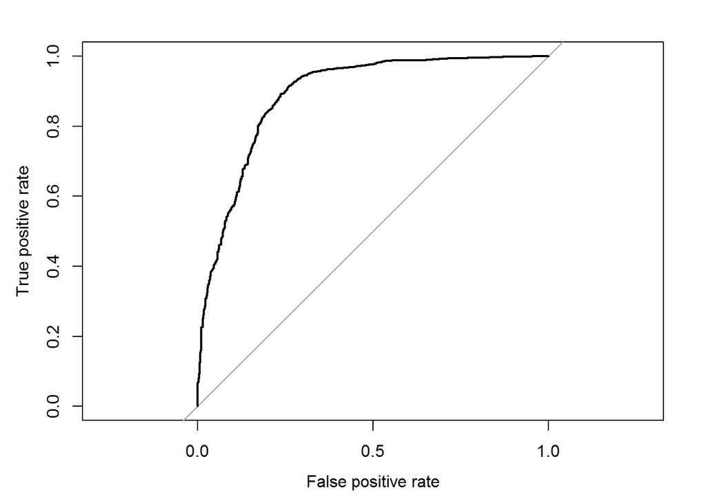

```r
pre <- predict(b,type = 'response') #根据模型结果进行预测
modelroc1 <- roc(hotpot$high,pre)  #绘制ROC曲线
plot.roc(modelroc1,xlab = "False positive rate",ylab = "True positive rate", xlim = c(1,0),legacy.axes = TRUE)
```

```r
auc(modelroc1) #计算AUC值
```

```
## Area under the curve: 0.8897
```

从ROC曲线图中得出，ROC曲线偏离45度对角线，接近(0,1)点，AUC值为0.89，证明逻辑斯蒂回归结果较好，模型分类效果较好。